# svc_norm.r

jflournoy

Tue Aug 18 12:30:19 2015

# Descriptives

These histograms by themselves tell a really interesting story – you can see that there is a some overlap between Acc and Cont ratings, but some items distinguish between them. These line up with a lot of our *a priori* ideas – see anger and jealousy. Pretty cool.

Aside from the status items, you also can see the scores on depression and substance use, among other things. Keep in mind the middle 2 CES_D items are reverse coded. SES ladder is mostly between 3-7 on a 9 point scale.

[figure not shown]

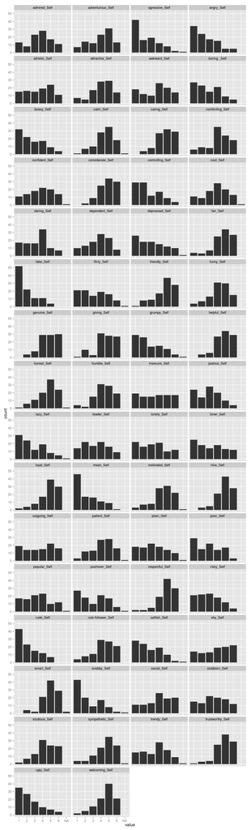

| desc | skew | pval | mean | sd |
| --- | --- | --- | --- | --- |
| insecure_Self | -0.0283501 | 0.9019713 | 3.490000 | 1.7551943 |
| daring_Self | -0.0369397 | 0.8725091 | 3.250000 | 1.4728177 |
| stubborn_Self | -0.0579809 | 0.8012135 | 3.490000 | 1.5858911 |
| leader_Self | 0.1027514 | 0.6559274 | 3.310000 | 1.5419717 |
| outgoing_Self | -0.1224289 | 0.5958376 | 3.550000 | 1.7602514 |
| popular_Self | 0.1436750 | 0.5359458 | 3.292929 | 1.5859879 |
| trendy_Self | -0.1445669 | 0.5334386 | 3.454546 | 1.5536181 |
| athletic_Self | -0.1573981 | 0.4961474 | 3.540000 | 1.6231905 |
| plain_Self | 0.1663235 | 0.4742817 | 3.232323 | 1.5896880 |
| pushover_Self | 0.1733206 | 0.4561013 | 3.010101 | 1.6567423 |
| confident_Self | -0.1805505 | 0.4377608 | 3.686869 | 1.5626147 |
| flirty_Self | 0.1910091 | 0.4120430 | 3.121212 | 1.6242595 |
| lonely_Self | 0.2134421 | 0.3580291 | 3.170000 | 1.6517820 |
| jealous_Self | 0.2166837 | 0.3509063 | 2.900000 | 1.4389952 |
| admired_Self | -0.2248039 | 0.3334858 | 3.610000 | 1.4832056 |
| loner_Self | 0.2408992 | 0.3007352 | 3.120000 | 1.7249213 |
| awkward_Self | -0.2509980 | 0.2813861 | 3.600000 | 1.6817499 |
| poor_Self | 0.2688930 | 0.2493376 | 2.840000 | 1.5486716 |
| dependent_Self | -0.3042124 | 0.1941856 | 3.650000 | 1.4310764 |
| risky_Self | 0.3162972 | 0.1776644 | 2.900000 | 1.4459976 |
| shy_Self | -0.3172830 | 0.1763672 | 3.850000 | 1.7196135 |
| cool_Self | -0.3321158 | 0.1595970 | 3.767677 | 1.4971284 |
| depressed_Self | 0.3563828 | 0.1324318 | 2.989899 | 1.6751177 |
| social_Self | -0.3708593 | 0.1164910 | 3.910000 | 1.6023657 |
| selfish_Self | 0.4277253 | 0.0737972 | 2.646465 | 1.4308063 |
| boring _Self | 0.4287829 | 0.0718664 | 2.770000 | 1.5166084 |
| patient_Self | -0.4599712 | 0.0557251 | 4.141414 | 1.3477881 |
| studious_Self | -0.4838010 | 0.0440607 | 4.370000 | 1.2764772 |
| adventurous_Self | -0.4871470 | 0.0427308 | 3.960000 | 1.4696938 |
| genuine_Self | -0.5502226 | 0.0235596 | 4.730000 | 1.0996326 |
| considerate_Self | -0.5567995 | 0.0221008 | 4.810000 | 1.0317681 |
| bossy_Self | 0.5578755 | 0.0218702 | 2.610000 | 1.5034976 |
| lazy_Self | 0.5746806 | 0.0190660 | 2.636364 | 1.5349968 |
| grumpy_Self | 0.5781332 | 0.0184309 | 2.646465 | 1.5139699 |
| caring_Self | -0.6049512 | 0.0137084 | 4.740000 | 1.0882290 |
| attractive_Self | -0.6192752 | 0.0118559 | 4.090000 | 1.3640033 |
| comforting_Self | -0.6278347 | 0.0108637 | 4.160000 | 1.3905889 |
| funny_Self | -0.6287765 | 0.0107594 | 4.210000 | 1.2815316 |
| rule-follower_Self | -0.6307734 | 0.0105414 | 4.300000 | 1.3521401 |
| controlling_Self | 0.6337901 | 0.0102200 | 2.600000 | 1.4839206 |
| calm_Self | -0.6507185 | 0.0088741 | 4.444444 | 1.1712737 |
| humble_Self | -0.6776478 | 0.0064745 | 4.360000 | 1.2351747 |
| helpful_Self | -0.6789290 | 0.0063877 | 4.780000 | 1.0596359 |
| agressive_Self | 0.7324172 | 0.0037556 | 2.333333 | 1.4356965 |
| giving_Self | -0.7483863 | 0.0030331 | 4.560000 | 1.2578642 |
| snobby_Self | 0.7502175 | 0.0031001 | 2.323232 | 1.4765395 |
| angry_Self | 0.7731570 | 0.0023127 | 2.480000 | 1.4666667 |
| honest_Self | -0.7748193 | 0.0023727 | 4.595960 | 1.2030505 |
| motivated_Self | -0.7847003 | 0.0021295 | 4.444444 | 1.2874767 |
| rude_Self | 0.8024367 | 0.0016730 | 2.170000 | 1.2953296 |
| mean_Self | 0.8178574 | 0.0014088 | 2.230000 | 1.4131775 |
| nice_Self | -0.8676875 | 0.0008039 | 4.880000 | 0.9773185 |
| welcoming_Self | -0.8746451 | 0.0007429 | 4.550000 | 1.2007994 |
| friendly_Self | -0.8770667 | 0.0007227 | 4.650000 | 1.2583057 |
| ugly_Self | 0.9027683 | 0.0005391 | 2.390000 | 1.4347421 |
| sympathetic_Self | -0.9293323 | 0.0004210 | 4.525252 | 1.3041804 |
| trustworthy_Self | -1.0070150 | 0.0001616 | 4.830000 | 1.0546195 |
| smart_Self | -1.0217586 | 0.0001552 | 4.918367 | 0.9809891 |
| fair_Self | -1.0710441 | 0.0000764 | 4.630000 | 1.2605514 |
| fake_Self | 1.0872091 | 0.0000632 | 1.930000 | 1.1997895 |
| loyal_Self | -1.1144612 | 0.0000458 | 4.770000 | 1.1964172 |
| respectful_Self | -1.2988493 | 0.0000052 | 4.870000 | 1.0885539 |

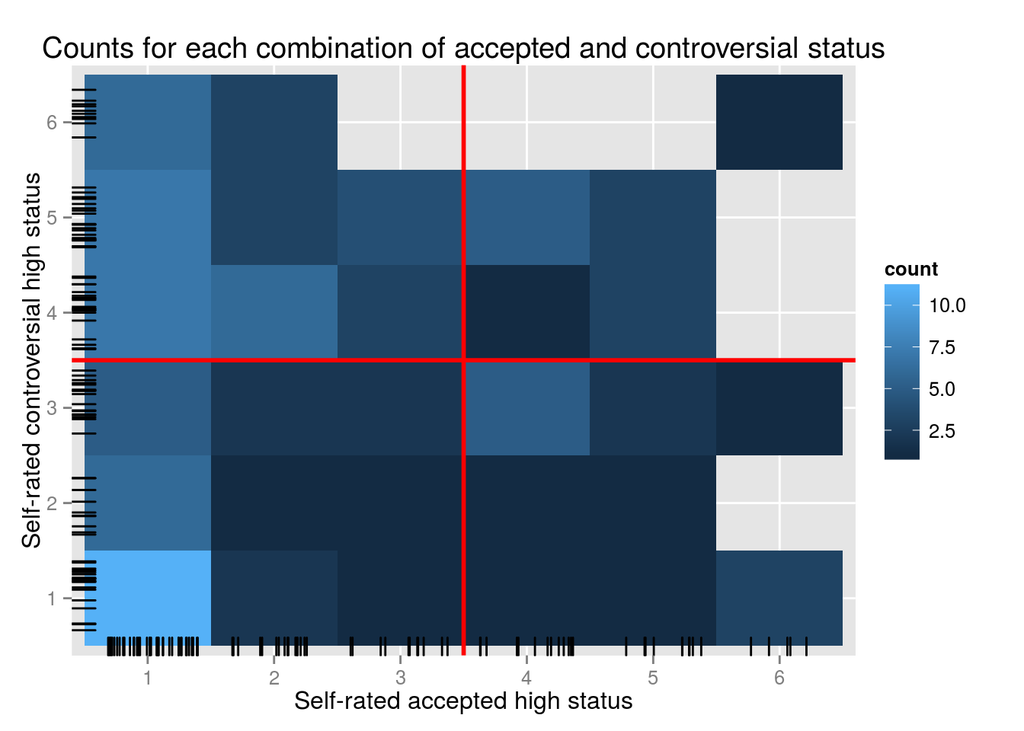

Controversial versus Accepted Status Frequencies

| Cont_v_Acc | 1 | 2 | 3 | 4 | 5 | 6 |
| --- | --- | --- | --- | --- | --- | --- |
| 1 | 11 | 6 | 5 | 7 | 7 | 6 |
| 2 | 2 | 1 | 2 | 6 | 3 | 3 |
| 3 | 1 | 1 | 2 | 3 | 4 | 0 |
| 4 | 1 | 1 | 5 | 1 | 5 | 0 |
| 5 | 1 | 1 | 2 | 3 | 3 | 0 |
| 6 | 3 | 0 | 1 | 0 | 0 | 1 |

# Self Ratings

## Best predictors of status

First thing, let’s see what items are best at predicting status using regularized regression for multinomial responses. This uses cross validation to give us the set of predictors that leads to the best out-of-sample prediction (least error).

The first plot shows how prediction error varies as a function of the number of parameters in the model, and how much weight each gets (the size of the coefficient).

The second set of plots actually show the size of each coefficient predicting both types of status as the constraint parameter, lambda, is tightened (left-to-right).

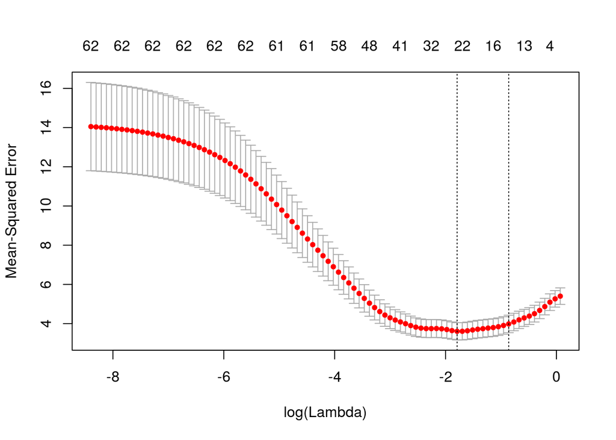

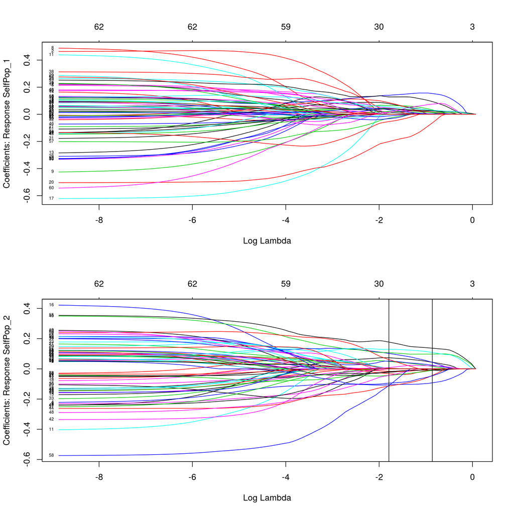

This table shows all the non-zero coefficients

Best predictors of self-report status

| xName | ContStat | AccStat |
| --- | --- | --- |
| (Intercept) | 1.424 | 2.787 |
| admired_Self | 0.079 | 0.074 |
| agressive_Self | 0.065 | 0.049 |
| angry_Self | 0.140 | -0.105 |
| awkward_Self | 0.016 | -0.023 |
| cool_Self | 0.047 | 0.052 |
| grumpy_Self | 0.043 | -0.043 |
| jealous_Self | 0.086 | -0.016 |
| leader_Self | -0.012 | 0.102 |
| mean_Self | 0.035 | 0.005 |
| poor_Self | 0.019 | -0.113 |
| popular_Self | 0.020 | 0.107 |
| risky_Self | 0.047 | -0.044 |
| rude_Self | 0.128 | -0.019 |
| rulefollower_Self | -0.054 | 0.061 |
| selfish_Self | 0.003 | -0.001 |
| shy_Self | 0.033 | -0.094 |
| snobby_Self | 0.014 | 0.008 |
| social_Self | 0.040 | 0.177 |
| studious_Self | -0.029 | 0.002 |
| trendy_Self | 0.055 | 0.130 |

While we’re interested in predicting status, we’re not actually asking about status. Rather, we’re asking about traits that we think relate to status. So while the above set of items might tell us who is likely to have one or the other kind of status, in the context of an fMRI analysis it would be hard to argue that activity observed during self evaluation of these traits is some measure of status-related brain activity.

## EFA to look at latent constructs

The more traditional approach would be to use EFA. What we hope to get is 2 factors the correspond to Accepted High Status and Controversial High Status.

However, the scree plot shows *very* clearly a 4 factor solution will account for most of the variance, with no real gain if we increase beyond 4.

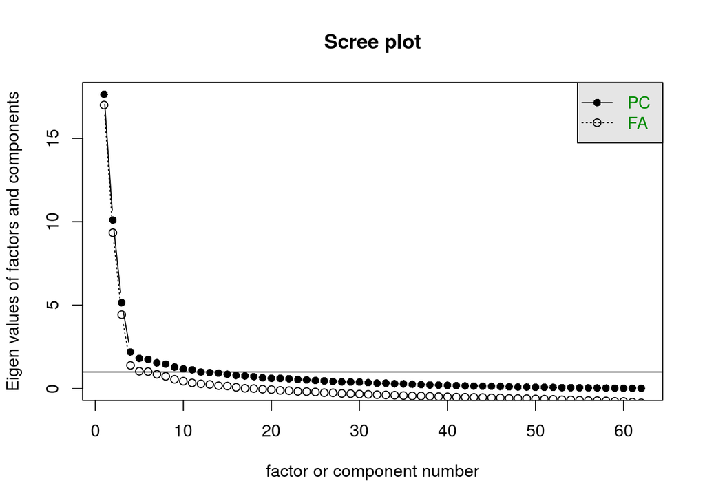

```
## Factor Analysis using method =  pa
## Call: fa(r = select(selfRateDat, -matches("SelfPop")), nfactors = 3,
##     rotate = "oblimin", scores = "tenBerge", fm = "pa", use = "pairwise.complete.obs")
## Standardized loadings (pattern matrix) based upon correlation matrix
##                    item   PA3   PA1   PA2   h2   u2 com
## insecure_Self        31 -0.86  0.09  0.20 0.72 0.28 1.1
## lonely_Self          35 -0.84  0.14  0.28 0.69 0.31 1.3
## depressed_Self       19 -0.82  0.10  0.29 0.69 0.31 1.3
## loner_Self           36 -0.79 -0.03  0.09 0.64 0.36 1.0
## awkward_Self          7 -0.78  0.16  0.26 0.59 0.41 1.3
## confident_Self       13  0.77  0.20  0.15 0.74 0.26 1.2
## trendy_Self          59  0.76  0.05  0.25 0.67 0.33 1.2
## shy_Self             52 -0.73  0.22 -0.02 0.49 0.51 1.2
## popular_Self         45  0.72  0.23  0.27 0.73 0.27 1.5
## social_Self          55  0.71  0.22  0.27 0.71 0.29 1.5
## plain_Self           43 -0.67  0.10  0.09 0.42 0.58 1.1
## flirty_Self          22  0.64  0.04  0.27 0.51 0.49 1.4
## boring _Self          8 -0.64 -0.03  0.23 0.46 0.54 1.3
## admired_Self          1  0.62  0.25  0.36 0.65 0.35 2.0
## outgoing_Self        41  0.62  0.14  0.24 0.52 0.48 1.4
## attractive_Self       6  0.61  0.33  0.22 0.63 0.37 1.8
## cool_Self            16  0.60  0.27  0.41 0.68 0.32 2.2
## ugly_Self            61 -0.59 -0.18  0.17 0.47 0.53 1.4
## leader_Self          34  0.57  0.12  0.32 0.49 0.51 1.7
## pushover_Self        46 -0.57  0.05  0.22 0.35 0.65 1.3
## adventurous_Self      2  0.50  0.29  0.33 0.51 0.49 2.4
## funny_Self           24  0.49  0.30  0.15 0.43 0.57 1.9
## poor_Self            44 -0.46 -0.22  0.33 0.45 0.55 2.3
## daring_Self          17  0.43  0.08  0.38 0.36 0.64 2.0
## athletic_Self         5  0.31  0.18  0.10 0.17 0.83 1.9
## nice_Self            40 -0.05  0.84 -0.10 0.73 0.27 1.0
## considerate_Self     14 -0.15  0.83 -0.10 0.69 0.31 1.1
## helpful_Self         28  0.08  0.79  0.03 0.66 0.34 1.0
## genuine_Self         25 -0.03  0.77 -0.02 0.58 0.42 1.0
## caring_Self          11  0.04  0.76 -0.02 0.59 0.41 1.0
## loyal_Self           37 -0.12  0.74  0.00 0.51 0.49 1.1
## friendly_Self        23  0.13  0.72 -0.02 0.59 0.41 1.1
## trustworthy_Self     60  0.11  0.72 -0.04 0.58 0.42 1.0
## giving_Self          26  0.04  0.71  0.03 0.52 0.48 1.0
## sympathetic_Self     58  0.00  0.71 -0.06 0.52 0.48 1.0
```

[output cut: 47 more lines]

```
## The root mean square of the residuals (RMSR) is  0.06
## The df corrected root mean square of the residuals is  0.06
##
## The harmonic number of observations is  99 with the empirical chi square  1373.9  with prob <  1
## The total number of observations was  100  with MLE Chi Square =  2583.27  with prob <  6.4e-39
##
## Tucker Lewis Index of factoring reliability =  0.727
## RMSEA index =  0.1  and the 90 % confidence intervals are  0.066 NA
## BIC =  -5282.36
## Fit based upon off diagonal values = 0.97
## Measures of factor score adequacy
##                                                 PA3  PA1  PA2
## Correlation of scores with factors             0.99 0.98 0.98
## Multiple R square of scores with factors       0.97 0.96 0.96
## Minimum correlation of possible factor scores  0.95 0.93 0.91
```

```
## Factor Analysis using method =  pa
## Call: fa(r = select(selfRateDat, -matches("SelfPop")), nfactors = 2,
##     rotate = "oblimin", scores = "tenBerge", fm = "pa", use = "pairwise.complete.obs")
## Standardized loadings (pattern matrix) based upon correlation matrix
##                    item   PA1   PA2    h2   u2 com
## popular_Self         45  0.85  0.02 0.730 0.27 1.0
## social_Self          55  0.84  0.01 0.714 0.29 1.0
## confident_Self       13  0.84  0.09 0.740 0.26 1.0
## trendy_Self          59  0.83 -0.10 0.674 0.33 1.0
## cool_Self            16  0.81 -0.07 0.641 0.36 1.0
## admired_Self          1  0.80 -0.05 0.635 0.37 1.0
## attractive_Self       6  0.76  0.12 0.620 0.38 1.1
## outgoing_Self        41  0.73 -0.04 0.520 0.48 1.0
## flirty_Self          22  0.72 -0.14 0.511 0.49 1.1
## loner_Self           36 -0.71 -0.15 0.567 0.43 1.1
## leader_Self          34  0.70 -0.12 0.482 0.52 1.1
## insecure_Self        31 -0.69 -0.14 0.537 0.46 1.1
## adventurous_Self      2  0.69  0.01 0.472 0.53 1.0
## shy_Self             52 -0.63  0.13 0.383 0.62 1.1
## lonely_Self          35 -0.62 -0.17 0.452 0.55 1.1
## depressed_Self       19 -0.62 -0.21 0.467 0.53 1.2
## funny_Self           24  0.61  0.15 0.420 0.58 1.1
## daring_Self          17  0.58 -0.20 0.342 0.66 1.2
## awkward_Self          7 -0.57 -0.13 0.371 0.63 1.1
## plain_Self           43 -0.56 -0.04 0.329 0.67 1.0
## ugly_Self            61 -0.53 -0.31 0.439 0.56 1.6
## boring _Self          8 -0.51 -0.25 0.366 0.63 1.4
## comforting_Self      12  0.44  0.36 0.383 0.62 1.9
## pushover_Self        46 -0.43 -0.17 0.238 0.76 1.3
## athletic_Self         5  0.39  0.09 0.169 0.83 1.1
## mean_Self            38  0.20 -0.79 0.607 0.39 1.1
## snobby_Self          54  0.23 -0.78 0.608 0.39 1.2
## rude_Self            49  0.25 -0.74 0.547 0.45 1.2
## nice_Self            40  0.15  0.73 0.587 0.41 1.1
## considerate_Self     14  0.05  0.71 0.525 0.48 1.0
## fake_Self            21 -0.05 -0.70 0.500 0.50 1.0
## agressive_Self        3  0.31 -0.69 0.503 0.50 1.4
## selfish_Self         51  0.07 -0.69 0.461 0.54 1.0
## welcoming_Self       62  0.24  0.65 0.538 0.46 1.3
## bossy_Self            9  0.47 -0.65 0.535 0.47 1.8
```

[output cut: 46 more lines]

```
## The root mean square of the residuals (RMSR) is  0.1
## The df corrected root mean square of the residuals is  0.1
##
## The harmonic number of observations is  99 with the empirical chi square  3502.54  with prob <  8.8e-117
## The total number of observations was  100  with MLE Chi Square =  3147.64  with prob <  1.2e-80
##
## Tucker Lewis Index of factoring reliability =  0.59
## RMSEA index =  0.115  and the 90 % confidence intervals are  0.083 NA
## BIC =  -4994.3
## Fit based upon off diagonal values = 0.91
## Measures of factor score adequacy
##                                                 PA1  PA2
## Correlation of scores with factors             0.99 0.98
## Multiple R square of scores with factors       0.97 0.96
## Minimum correlation of possible factor scores  0.95 0.93
```

Here’s the raw output, if you like, but see below for a prettier table. Notice the factors are allowed to correlate.

```
## Factor Analysis using method =  pa
## Call: fa(r = select(selfRateDat, -matches("SelfPop")), nfactors = 4,
##     rotate = "oblimin", scores = "tenBerge", fm = "pa", use = "pairwise.complete.obs")
## Standardized loadings (pattern matrix) based upon correlation matrix
##                    item   PA3   PA1   PA2   PA4   h2   u2 com
## depressed_Self       19  0.91  0.11  0.16  0.16 0.76 0.24 1.2
## insecure_Self        31  0.89  0.09  0.10  0.05 0.75 0.25 1.1
## lonely_Self          35  0.83  0.13  0.23 -0.05 0.69 0.31 1.2
## awkward_Self          7  0.83  0.16  0.16  0.08 0.62 0.38 1.2
## trendy_Self          59 -0.76  0.06  0.33 -0.01 0.72 0.28 1.4
## confident_Self       13 -0.76  0.21  0.21  0.01 0.76 0.24 1.3
## loner_Self           36  0.74 -0.05  0.08 -0.12 0.64 0.36 1.1
## popular_Self         45 -0.69  0.24  0.30  0.06 0.74 0.26 1.7
## plain_Self           43  0.66  0.09  0.06 -0.05 0.42 0.58 1.1
## shy_Self             52  0.62  0.19  0.05 -0.28 0.51 0.49 1.6
## social_Self          55 -0.60  0.25  0.21  0.27 0.72 0.28 2.1
## boring _Self          8  0.57 -0.05  0.27 -0.19 0.48 0.52 1.7
## outgoing_Self        41 -0.56  0.17  0.23  0.14 0.52 0.48 1.7
## flirty_Self          22 -0.55  0.06  0.24  0.21 0.51 0.49 1.7
## admired_Self          1 -0.55  0.27  0.34  0.17 0.65 0.35 2.4
## cool_Self            16 -0.54  0.29  0.41  0.12 0.68 0.32 2.6
## leader_Self          34 -0.54  0.13  0.34  0.07 0.49 0.51 1.9
## ugly_Self            61  0.53 -0.20  0.19 -0.14 0.48 0.52 1.7
## pushover_Self        46  0.52  0.04  0.24 -0.14 0.35 0.65 1.6
## poor_Self            44  0.50 -0.22  0.26  0.08 0.46 0.54 2.0
## attractive_Self       6 -0.50  0.36  0.15  0.26 0.64 0.36 2.6
## funny_Self           24 -0.37  0.33  0.06  0.28 0.45 0.55 2.9
## athletic_Self         5 -0.28  0.20  0.10  0.07 0.17 0.83 2.2
## nice_Self            40  0.09  0.85 -0.16  0.06 0.74 0.26 1.1
## considerate_Self     14  0.18  0.84 -0.15  0.03 0.70 0.30 1.2
## helpful_Self         28  0.00  0.81 -0.06  0.15 0.69 0.31 1.1
## caring_Self          11  0.04  0.77 -0.10  0.14 0.62 0.38 1.1
## genuine_Self         25 -0.01  0.76  0.02 -0.14 0.59 0.41 1.1
## loyal_Self           37  0.09  0.73  0.02 -0.11 0.51 0.49 1.1
## trustworthy_Self     60 -0.05  0.73 -0.09  0.10 0.60 0.40 1.1
## friendly_Self        23 -0.11  0.72 -0.03  0.01 0.59 0.41 1.0
## giving_Self          26 -0.03  0.71  0.02  0.00 0.52 0.48 1.0
## sympathetic_Self     58  0.00  0.71 -0.05 -0.04 0.52 0.48 1.0
## welcoming_Self       62 -0.08  0.69 -0.18  0.05 0.59 0.41 1.2
## fair_Self            20 -0.08  0.59 -0.18 -0.08 0.46 0.54 1.3
```

[output cut: 48 more lines]

```
## The root mean square of the residuals (RMSR) is  0.05
## The df corrected root mean square of the residuals is  0.06
##
## The harmonic number of observations is  99 with the empirical chi square  1098.85  with prob <  1
## The total number of observations was  100  with MLE Chi Square =  2418.93  with prob <  3e-32
##
## Tucker Lewis Index of factoring reliability =  0.748
## RMSEA index =  0.097  and the 90 % confidence intervals are  0.062 NA
## BIC =  -5175
## Fit based upon off diagonal values = 0.97
## Measures of factor score adequacy
##                                                 PA3  PA1  PA2  PA4
## Correlation of scores with factors             0.99 0.98 0.98 0.93
## Multiple R square of scores with factors       0.98 0.97 0.96 0.87
## Minimum correlation of possible factor scores  0.96 0.93 0.91 0.73
```

The four factors are pretty interpretable, if you ask me.

1. First (PA3), is surgency/dynamism/extraversion (reverse coded ’cause EFA): not depressed, lonely, or insecure; trendy, confident, popular, social.
2. Second (PA1), we have prosociality: caring, fair, helpful, loyal (guidelines for a model girl scout, basically).
3. Third (PA2), we have…aggression? Rude, mean, bossy, snobby, as well as lazy and fake.
4. Finally, fourth (PA4), daring, risky, adventurous, and not rule following.

Here’s nice table:

| item | PA3 | PA1 | PA2 | PA4 | comm |
| --- | --- | --- | --- | --- | --- |
| depressed_Self | 0.91 | 0.11 | 0.16 | 0.16 | 0.758 |
| insecure_Self | 0.89 |  | 0.10 |  | 0.745 |
| lonely_Self | 0.83 | 0.13 | 0.23 |  | 0.692 |
| awkward_Self | 0.83 | 0.16 | 0.16 |  | 0.620 |
| trendy_Self | -0.76 |  | 0.33 |  | 0.715 |
| confident_Self | -0.76 | 0.21 | 0.21 |  | 0.762 |
| loner_Self | 0.74 |  |  | -0.12 | 0.642 |
| popular_Self | -0.69 | 0.24 | 0.30 |  | 0.743 |
| plain_Self | 0.66 |  |  |  | 0.424 |
| shy_Self | 0.62 | 0.19 |  | -0.28 | 0.506 |
| social_Self | -0.60 | 0.25 | 0.21 | 0.27 | 0.720 |
| boring _Self | 0.57 |  | 0.27 | -0.19 | 0.479 |
| outgoing_Self | -0.56 | 0.17 | 0.23 | 0.14 | 0.517 |
| flirty_Self | -0.55 |  | 0.24 | 0.21 | 0.508 |
| admired_Self | -0.55 | 0.27 | 0.34 | 0.17 | 0.653 |
| cool_Self | -0.54 | 0.29 | 0.41 | 0.12 | 0.680 |
| leader_Self | -0.54 | 0.13 | 0.34 |  | 0.495 |
| ugly_Self | 0.53 | -0.20 | 0.19 | -0.14 | 0.479 |
| pushover_Self | 0.52 |  | 0.24 | -0.14 | 0.352 |
| poor_Self | 0.50 | -0.22 | 0.26 |  | 0.459 |
| attractive_Self | -0.50 | 0.36 | 0.15 | 0.26 | 0.641 |
| funny_Self | -0.37 | 0.33 |  | 0.28 | 0.454 |
| athletic_Self | -0.28 | 0.20 |  |  | 0.171 |
| nice_Self |  | 0.85 | -0.16 |  | 0.743 |
| considerate_Self | 0.18 | 0.84 | -0.15 |  | 0.699 |
| helpful_Self |  | 0.81 |  | 0.15 | 0.689 |
| caring_Self |  | 0.77 |  | 0.14 | 0.625 |
| genuine_Self |  | 0.76 |  | -0.14 | 0.590 |
| loyal_Self |  | 0.73 |  | -0.11 | 0.514 |
| trustworthy_Self |  | 0.73 |  | 0.10 | 0.597 |
| friendly_Self | -0.11 | 0.72 |  |  | 0.591 |
| giving_Self |  | 0.71 |  |  | 0.516 |
| sympathetic_Self |  | 0.71 |  |  | 0.520 |
| welcoming_Self |  | 0.69 | -0.18 |  | 0.590 |
| fair_Self |  | 0.59 | -0.18 |  | 0.456 |
| humble_Self | 0.21 | 0.55 | -0.18 | -0.13 | 0.382 |
| respectful_Self | -0.17 | 0.55 | 0.13 | -0.44 | 0.508 |
| calm_Self | -0.22 | 0.54 |  | -0.19 | 0.460 |
| honest_Self | -0.24 | 0.49 |  | -0.11 | 0.403 |
| smart_Self |  | 0.46 | -0.12 |  | 0.243 |
| motivated_Self | -0.25 | 0.44 |  | -0.25 | 0.348 |
| studious_Self |  | 0.44 |  | -0.34 | 0.296 |
| comforting_Self | -0.34 | 0.44 |  |  | 0.397 |
| patient_Self | -0.18 | 0.42 | -0.22 | -0.12 | 0.362 |
| mean_Self |  | -0.32 | 0.75 |  | 0.722 |
| controlling_Self | -0.19 |  | 0.74 |  | 0.631 |
| snobby_Self |  | -0.28 | 0.73 |  | 0.701 |
| rude_Self |  | -0.25 | 0.72 |  | 0.650 |
| bossy_Self | -0.17 | -0.12 | 0.70 | 0.13 | 0.623 |
| angry_Self | 0.38 |  | 0.65 | 0.12 | 0.640 |
| grumpy_Self | 0.46 |  | 0.62 |  | 0.623 |
| agressive_Self |  | -0.23 | 0.61 | 0.17 | 0.553 |
| selfish_Self | 0.17 | -0.26 | 0.54 | 0.17 | 0.522 |
| jealous_Self | 0.42 |  | 0.52 |  | 0.439 |
| lazy_Self | 0.17 | -0.16 | 0.48 |  | 0.331 |
| fake_Self | 0.16 | -0.40 | 0.47 |  | 0.515 |
| dependent_Self | 0.22 | 0.16 | 0.45 | -0.17 | 0.235 |
| stubborn_Self | 0.16 | 0.14 | 0.37 | 0.22 | 0.224 |
| daring_Self | -0.15 | 0.15 | 0.13 | 0.67 | 0.616 |
| risky_Self |  |  | 0.22 | 0.63 | 0.503 |
| rule-follower_Self |  | 0.44 | 0.20 | -0.59 | 0.492 |
| adventurous_Self | -0.31 | 0.34 | 0.17 | 0.45 | 0.596 |

I think this plot is supposed to show how much separation we get.

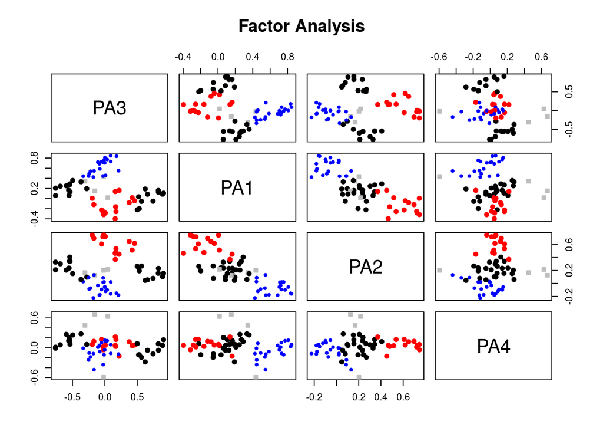

These clusters of items may still be related to status (and they’re actually pretty close to the expected factors, just divided up a bit more). We can correlate self rated accepted and controversial status with the factor scores to start exploring this.

### Correlations

In the output below, SelfPop_1 is controversial, and SelfPop_2 is accepted.

Also:

1. Surgency/dynamism (PA3)
2. Prosociality (PA1)
3. Aggression (PA2)
4. Daring (PA4)

We see that controversial status is correlated with aggression and with risk-taking.

We see accepted status is highly correlated with the surgency/dynamism component (remember, reverse the sign here because of the depression item anchoring the scale).

```
## Call:corr.test(x = as.data.frame(selfPopDat), y = as.data.frame(predict(selfRateFA,
##     selfRateDat_nopop_imputed, missing = T, use = "pairwise.complete.obs")),
##     use = "pairwise.complete.obs", adjust = "none")
## Correlation matrix
##              V1    V2   V3   V4
## SelfPop_1  0.04 -0.18 0.53 0.22
## SelfPop_2 -0.70  0.13 0.12 0.08
## Sample Size
##            V1  V2  V3  V4
## SelfPop_1  98  98  98  98
## SelfPop_2 100 100 100 100
##             V1   V2   V3   V4
## SelfPop_1 0.68 0.08 0.00 0.03
## SelfPop_2 0.00 0.19 0.23 0.44
##
##  To see confidence intervals of the correlations, print with the short=FALSE option
```

Grain of salt: No correction for multiple comparison here.

Slightly bigger grain of salt: 8 folks are missing a rating on a couple items here and there, so I impute the mean so we can get predicted factor scores. This means that significance values and CIs close to threshold below should be treated lightly (but it doesn’t change things too much).

This gets more interesting in the regressions.

### Regressing Controversial Status

Here’s the raw output for regressing controversial status on the component scores – see below for a table with CIs.

```
##
## Call: rlm(formula = selfPopDat[, c("SelfPop_1")] ~ predict(selfRateFA,
##     selfRateDat_nopop_imputed))
## Residuals:
##      Min       1Q   Median       3Q      Max
## -3.24023 -0.68406 -0.03696  0.62288  3.78772
##
## Coefficients:
##                                                 Value   Std. Error t value
## (Intercept)                                      2.3015  0.1179    19.5132
## predict(selfRateFA, selfRateDat_nopop_imputed)1  0.0389  0.1184     0.3288
## predict(selfRateFA, selfRateDat_nopop_imputed)2 -0.3720  0.1184    -3.1422
## predict(selfRateFA, selfRateDat_nopop_imputed)3  0.9436  0.1181     7.9900
## predict(selfRateFA, selfRateDat_nopop_imputed)4  0.2671  0.1184     2.2549
##
## Residual standard error: 0.9783 on 93 degrees of freedom
##   (2 observations deleted due to missingness)
```

Results from bootstrap estimates: Controversial status is significantly predicted by lower prosocial scores (2), and higher aggression scores (3). Estimates for risk-taking (4) is positive and just past threshold.

Controversial status relation with component scores, bootstrapped CIs

| component | est | lower 95% | upper 95% |
| --- | --- | --- | --- |
| 1 | 0.04 | -0.16 | 0.29 |
| 2 | -0.37 | -0.73 | -0.12 |
| 3 | 0.94 | 0.64 | 1.21 |
| 4 | 0.27 | 0.02 | 0.65 |

### Regressing Accepted Status

Here’s the raw output for an rlm of accepted status on the component scores. Again, scroll down for a nice table.

```
##
## Call: rlm(formula = selfPopDat[, c("SelfPop_2")] ~ predict(selfRateFA,
##     selfRateDat_nopop_imputed))
## Residuals:
##        Min         1Q     Median         3Q        Max
## -3.4231128 -0.6660494 -0.0005848  0.5692945  2.7964611
##
## Coefficients:
##                                                 Value    Std. Error
## (Intercept)                                       3.5353   0.1105
## predict(selfRateFA, selfRateDat_nopop_imputed)1  -1.2378   0.1110
## predict(selfRateFA, selfRateDat_nopop_imputed)2   0.2579   0.1111
## predict(selfRateFA, selfRateDat_nopop_imputed)3   0.2977   0.1111
## predict(selfRateFA, selfRateDat_nopop_imputed)4   0.1028   0.1109
##                                                 t value
## (Intercept)                                      31.9866
## predict(selfRateFA, selfRateDat_nopop_imputed)1 -11.1509
## predict(selfRateFA, selfRateDat_nopop_imputed)2   2.3210
## predict(selfRateFA, selfRateDat_nopop_imputed)3   2.6792
## predict(selfRateFA, selfRateDat_nopop_imputed)4   0.9275
##
## Residual standard error: 0.8834 on 95 degrees of freedom
```

Accepted status is significantly predicted by higher surgency (1; remember, flip the sign), and prosocial scores (2). Interestingly aggression (3) is also significant.

Accepted status relation with component scores, bootstrapped CIs

| component | est | lower 95% | upper 95% |
| --- | --- | --- | --- |
| 1 | -1.24 | -1.44 | -0.98 |
| 2 | 0.26 | 0.03 | 0.45 |
| 3 | 0.30 | 0.03 | 0.54 |
| 4 | 0.10 | -0.21 | 0.42 |

### What has EFA told us?

Well, we have four factors that are helpfully related to self reported status. This is what we want. All four factors seem relevant.

## EFA using machine learning to select items

Now we need a principled way to select items. We could use some communality cutoff, or loading strength. But we know we want 48 items, so let’s start there. We can use regularized regression methods to let the machine learn what 48 items give us the best set of factors. We can then compare that to the EFA results as well as to the earlier classification.

```
## iterations 10
## iterations 20
## iterations 30
## iterations 10
## iterations 20
## iterations 30
## iterations 10
## iterations 20
## iterations 30
## iterations 10
## iterations 20
## iterations 10
## iterations 20
## iterations 10
## iterations 20
```

```
## [[1]]
##   para Nitems
##      1     56
##
## [[2]]
##   para Nitems
##    1.2   52.0
##
## [[3]]
##   para Nitems
##    1.4   48.0
##
## [[4]]
##   para Nitems
##    1.6   46.0
##
## [[5]]
##   para Nitems
##    1.8   45.0
##
## [[6]]
##   para Nitems
##      2     38
```

A penalty parameter of 1.4 (#3) gives us the number of items we want (48 unique).

|  | PC1 | PC2 | PC3 | PC4 |
| --- | --- | --- | --- | --- |
| admired_Self | -0.102 |  |  |  |
| adventurous_Self |  |  |  | -0.08 |
| agressive_Self |  | 0.094 |  |  |
| angry_Self |  | 0.399 |  |  |
| athletic_Self |  |  |  |  |
| attractive_Self | -0.226 |  |  |  |
| awkward_Self | 0.288 |  |  |  |
| boring _Self | 0.063 |  |  |  |
| bossy_Self |  | 0.451 |  |  |
| calm_Self |  |  | -0.098 |  |
| caring_Self |  |  | -0.045 |  |
| comforting_Self |  |  |  |  |
| confident_Self | -0.355 |  |  |  |
| considerate_Self |  |  | -0.096 |  |
| controlling_Self |  | 0.285 |  |  |
| cool_Self | -0.11 |  |  |  |
| daring_Self |  |  |  | -0.739 |
| dependent_Self |  |  |  |  |
| depressed_Self | 0.302 |  |  |  |
| fair_Self |  |  | -0.056 |  |
| fake_Self |  |  |  |  |
| flirty_Self |  |  |  |  |
| friendly_Self |  |  | -0.49 |  |
| funny_Self |  |  |  |  |
| genuine_Self |  |  | -0.243 |  |
| giving_Self |  |  | -0.261 |  |
| grumpy_Self |  | 0.212 |  |  |
| helpful_Self |  |  | -0.449 |  |
| honest_Self |  |  |  |  |
| humble_Self |  |  | -0.026 |  |
| insecure_Self | 0.438 |  |  |  |
| jealous_Self |  | 0.085 |  |  |
| lazy_Self |  | 0.08 |  |  |
| leader_Self | -0.088 |  |  |  |
| lonely_Self | 0.234 |  |  |  |
| loner_Self | 0.334 |  |  |  |
| loyal_Self |  |  | -0.474 |  |
| mean_Self |  | 0.416 |  |  |
| motivated_Self |  |  | -0.056 |  |
| nice_Self |  |  | -0.195 |  |
| outgoing_Self | -0.142 |  |  |  |
| patient_Self |  |  |  |  |
| plain_Self | 0.053 |  |  |  |
| poor_Self | 0.018 |  |  |  |
| popular_Self | -0.323 |  |  |  |
| pushover_Self | 0.043 |  |  |  |
| respectful_Self |  |  |  |  |
| risky_Self |  |  |  | -0.669 |
| rude_Self |  |  |  |  |
| rule-follower_Self |  |  | -0.092 |  |
| selfish_Self |  | 0.085 |  |  |
| shy_Self | 0.153 |  |  |  |
| smart_Self |  |  |  |  |
| snobby_Self |  | 0.556 |  |  |
| social_Self | -0.291 |  |  |  |
| stubborn_Self |  |  |  |  |
| studious_Self |  |  | -0.076 |  |
| sympathetic_Self |  |  | -0.355 |  |
| trendy_Self | -0.116 |  |  |  |
| trustworthy_Self |  |  |  |  |
| ugly_Self | 0.074 |  |  |  |
| welcoming_Self |  |  |  |  |

The next obvious step is to look and see what a regular EFA tells us about this selection of items

Whammo, 4 factors again.

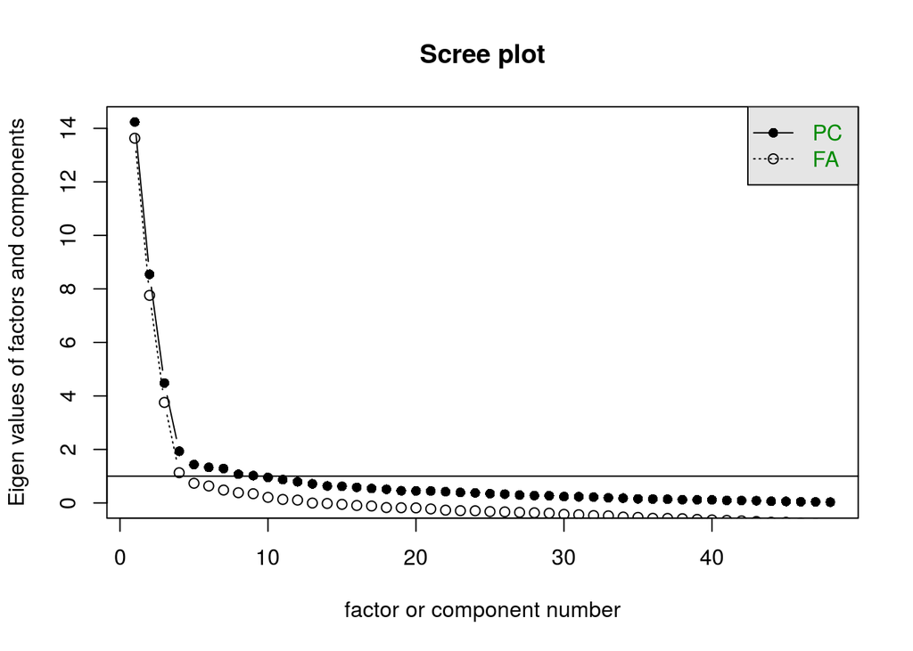

```
## Factor Analysis using method =  pa
## Call: fa(r = eItemDF, nfactors = 4, rotate = "oblimin", scores = "tenBerge",
##     fm = "pa", use = "pairwise.complete.obs")
## Standardized loadings (pattern matrix) based upon correlation matrix
##                    item   PA1   PA3   PA2   PA4   h2   u2 com
## depressed_Self       16  0.92  0.09  0.09  0.19 0.77 0.23 1.1
## insecure_Self        24  0.89  0.08  0.06  0.01 0.74 0.26 1.0
## lonely_Self          28  0.84  0.12  0.19 -0.06 0.70 0.30 1.2
## awkward_Self          6  0.82  0.15  0.13  0.04 0.61 0.39 1.1
## loner_Self           29  0.75 -0.05  0.05 -0.14 0.65 0.35 1.1
## confident_Self       11 -0.73  0.21  0.27  0.01 0.76 0.24 1.5
## trendy_Self          47 -0.72  0.06  0.37  0.01 0.71 0.29 1.5
## plain_Self           35  0.66  0.10  0.06 -0.10 0.43 0.57 1.1
## popular_Self         37 -0.65  0.26  0.34  0.07 0.75 0.25 1.9
## shy_Self             42  0.64  0.19 -0.01 -0.24 0.50 0.50 1.5
## boring _Self          7  0.60 -0.05  0.24 -0.18 0.48 0.52 1.5
## pushover_Self        38  0.57  0.05  0.21 -0.10 0.36 0.64 1.3
## social_Self          44 -0.57  0.25  0.24  0.28 0.72 0.28 2.3
## ugly_Self            48  0.56 -0.19  0.15 -0.11 0.48 0.52 1.5
## poor_Self            36  0.52 -0.23  0.24  0.08 0.46 0.54 1.9
## leader_Self          27 -0.52  0.13  0.41  0.01 0.51 0.49 2.0
## outgoing_Self        34 -0.51  0.18  0.26  0.18 0.52 0.48 2.1
## admired_Self          1 -0.51  0.26  0.39  0.17 0.66 0.34 2.7
## cool_Self            14 -0.50  0.29  0.43  0.16 0.69 0.31 2.8
## attractive_Self       5 -0.48  0.34  0.18  0.25 0.62 0.38 2.7
## jealous_Self         25  0.47 -0.01  0.46  0.08 0.43 0.57 2.1
## nice_Self            33  0.08  0.84 -0.17  0.08 0.74 0.26 1.1
## considerate_Self     12  0.16  0.84 -0.16  0.02 0.70 0.30 1.1
## helpful_Self         22 -0.01  0.80 -0.08  0.17 0.68 0.32 1.1
## caring_Self          10  0.02  0.78 -0.09  0.12 0.63 0.37 1.1
## genuine_Self         19 -0.02  0.74  0.02 -0.12 0.56 0.44 1.1
## giving_Self          20 -0.01  0.73 -0.02  0.05 0.54 0.46 1.0
## friendly_Self        18 -0.12  0.72  0.00  0.00 0.58 0.42 1.1
## loyal_Self           30  0.08  0.72  0.02 -0.11 0.49 0.51 1.1
## sympathetic_Self     46  0.00  0.71 -0.07 -0.02 0.53 0.47 1.0
## fair_Self            17 -0.10  0.59 -0.15 -0.10 0.46 0.54 1.3
## humble_Self          23  0.19  0.55 -0.19 -0.12 0.37 0.63 1.6
## calm_Self             9 -0.24  0.54 -0.01 -0.23 0.47 0.53 1.8
## motivated_Self       32 -0.29  0.44  0.17 -0.36 0.42 0.58 3.0
## studious_Self        45 -0.05  0.42  0.12 -0.40 0.32 0.68 2.2
```

[output cut: 34 more lines]

```
## The root mean square of the residuals (RMSR) is  0.05
## The df corrected root mean square of the residuals is  0.05
##
## The harmonic number of observations is  99 with the empirical chi square  543.27  with prob <  1
## The total number of observations was  100  with MLE Chi Square =  1360.84  with prob <  8e-18
##
## Tucker Lewis Index of factoring reliability =  0.821
## RMSEA index =  0.09  and the 90 % confidence intervals are  0.059 NA
## BIC =  -2977.23
## Fit based upon off diagonal values = 0.98
## Measures of factor score adequacy
##                                                 PA1  PA3  PA2  PA4
## Correlation of scores with factors             0.98 0.98 0.97 0.92
## Multiple R square of scores with factors       0.97 0.95 0.94 0.85
## Minimum correlation of possible factor scores  0.94 0.91 0.88 0.70
```

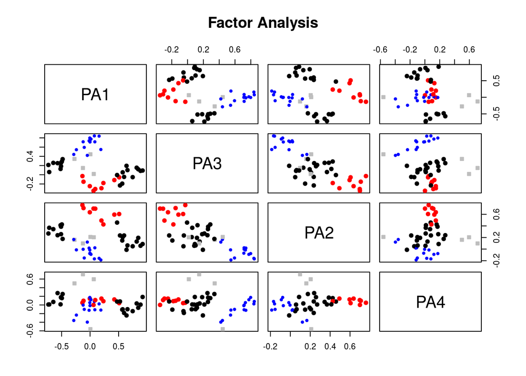

| item | PA1 | PA3 | PA2 | PA4 | comm |
| --- | --- | --- | --- | --- | --- |
| depressed_Self | 0.92 |  |  | 0.19 | 0.77 |
| insecure_Self | 0.89 |  |  |  | 0.74 |
| lonely_Self | 0.84 | 0.12 | 0.19 |  | 0.70 |
| awkward_Self | 0.82 | 0.15 | 0.13 |  | 0.61 |
| loner_Self | 0.75 |  |  | -0.14 | 0.65 |
| confident_Self | -0.73 | 0.21 | 0.27 |  | 0.76 |
| trendy_Self | -0.72 |  | 0.37 |  | 0.71 |
| plain_Self | 0.66 | 0.10 |  |  | 0.43 |
| popular_Self | -0.65 | 0.26 | 0.34 |  | 0.75 |
| shy_Self | 0.64 | 0.19 |  | -0.24 | 0.50 |
| boring _Self | 0.60 |  | 0.24 | -0.18 | 0.48 |
| pushover_Self | 0.57 |  | 0.21 | -0.10 | 0.36 |
| social_Self | -0.57 | 0.25 | 0.24 | 0.28 | 0.72 |
| ugly_Self | 0.56 | -0.19 | 0.15 | -0.11 | 0.48 |
| poor_Self | 0.52 | -0.23 | 0.24 |  | 0.46 |
| leader_Self | -0.52 | 0.13 | 0.41 |  | 0.51 |
| outgoing_Self | -0.51 | 0.18 | 0.26 | 0.18 | 0.52 |
| admired_Self | -0.51 | 0.26 | 0.39 | 0.17 | 0.66 |
| cool_Self | -0.50 | 0.29 | 0.43 | 0.16 | 0.69 |
| attractive_Self | -0.48 | 0.34 | 0.18 | 0.25 | 0.62 |
| jealous_Self | 0.47 |  | 0.46 |  | 0.43 |
| nice_Self |  | 0.84 | -0.17 |  | 0.74 |
| considerate_Self | 0.16 | 0.84 | -0.16 |  | 0.70 |
| helpful_Self |  | 0.80 |  | 0.17 | 0.68 |
| caring_Self |  | 0.78 |  | 0.12 | 0.63 |
| genuine_Self |  | 0.74 |  | -0.12 | 0.56 |
| giving_Self |  | 0.73 |  |  | 0.54 |
| friendly_Self | -0.12 | 0.72 |  |  | 0.58 |
| loyal_Self |  | 0.72 |  | -0.11 | 0.49 |
| sympathetic_Self |  | 0.71 |  |  | 0.53 |
| fair_Self | -0.10 | 0.59 | -0.15 | -0.10 | 0.46 |
| humble_Self | 0.19 | 0.55 | -0.19 | -0.12 | 0.37 |
| calm_Self | -0.24 | 0.54 |  | -0.23 | 0.47 |
| motivated_Self | -0.29 | 0.44 | 0.17 | -0.36 | 0.42 |
| studious_Self |  | 0.42 | 0.12 | -0.40 | 0.32 |
| controlling_Self | -0.13 |  | 0.76 |  | 0.64 |
| bossy_Self | -0.12 | -0.15 | 0.71 |  | 0.62 |
| mean_Self |  | -0.35 | 0.70 |  | 0.68 |
| snobby_Self |  | -0.31 | 0.70 | 0.11 | 0.71 |
| agressive_Self |  | -0.25 | 0.64 | 0.15 | 0.58 |
| grumpy_Self | 0.51 |  | 0.61 |  | 0.64 |
| angry_Self | 0.43 | -0.12 | 0.60 | 0.13 | 0.61 |
| selfish_Self | 0.20 | -0.29 | 0.49 | 0.15 | 0.49 |
| lazy_Self | 0.23 | -0.18 | 0.43 |  | 0.33 |
| daring_Self | -0.13 | 0.15 |  | 0.71 | 0.64 |
| risky_Self |  |  | 0.20 | 0.60 | 0.46 |
| rule-follower_Self |  | 0.44 | 0.21 | -0.56 | 0.46 |
| adventurous_Self | -0.27 | 0.34 | 0.16 | 0.50 | 0.63 |

For reference, the original EFA with items that also appear above in bold.

Original EFA, retained items bolded

| item | PA3 | PA1 | PA2 | PA4 | comm |
| --- | --- | --- | --- | --- | --- |
| **depressed_Self** | 0.91 | 0.11 | 0.16 | 0.16 | 0.758 |
| **insecure_Self** | 0.89 |  | 0.10 |  | 0.745 |
| **lonely_Self** | 0.83 | 0.13 | 0.23 |  | 0.692 |
| **awkward_Self** | 0.83 | 0.16 | 0.16 |  | 0.620 |
| **trendy_Self** | -0.76 |  | 0.33 |  | 0.715 |
| **confident_Self** | -0.76 | 0.21 | 0.21 |  | 0.762 |
| **loner_Self** | 0.74 |  |  | -0.12 | 0.642 |
| **popular_Self** | -0.69 | 0.24 | 0.30 |  | 0.743 |
| **plain_Self** | 0.66 |  |  |  | 0.424 |
| **shy_Self** | 0.62 | 0.19 |  | -0.28 | 0.506 |
| **social_Self** | -0.60 | 0.25 | 0.21 | 0.27 | 0.720 |
| **boring_Self** | 0.57 |  | 0.27 | -0.19 | 0.479 |
| **outgoing_Self** | -0.56 | 0.17 | 0.23 | 0.14 | 0.517 |
| flirty_Self | -0.55 |  | 0.24 | 0.21 | 0.508 |
| **admired_Self** | -0.55 | 0.27 | 0.34 | 0.17 | 0.653 |
| **cool_Self** | -0.54 | 0.29 | 0.41 | 0.12 | 0.680 |
| **leader_Self** | -0.54 | 0.13 | 0.34 |  | 0.495 |
| **ugly_Self** | 0.53 | -0.20 | 0.19 | -0.14 | 0.479 |
| **pushover_Self** | 0.52 |  | 0.24 | -0.14 | 0.352 |
| **poor_Self** | 0.50 | -0.22 | 0.26 |  | 0.459 |
| **attractive_Self** | -0.50 | 0.36 | 0.15 | 0.26 | 0.641 |
| funny_Self | -0.37 | 0.33 |  | 0.28 | 0.454 |
| athletic_Self | -0.28 | 0.20 |  |  | 0.171 |
| **nice_Self** |  | 0.85 | -0.16 |  | 0.743 |
| **considerate_Self** | 0.18 | 0.84 | -0.15 |  | 0.699 |
| **helpful_Self** |  | 0.81 |  | 0.15 | 0.689 |
| **caring_Self** |  | 0.77 |  | 0.14 | 0.625 |
| **genuine_Self** |  | 0.76 |  | -0.14 | 0.590 |
| **loyal_Self** |  | 0.73 |  | -0.11 | 0.514 |
| trustworthy_Self |  | 0.73 |  | 0.10 | 0.597 |
| **friendly_Self** | -0.11 | 0.72 |  |  | 0.591 |
| **giving_Self** |  | 0.71 |  |  | 0.516 |
| **sympathetic_Self** |  | 0.71 |  |  | 0.520 |
| welcoming_Self |  | 0.69 | -0.18 |  | 0.590 |
| **fair_Self** |  | 0.59 | -0.18 |  | 0.456 |
| **humble_Self** | 0.21 | 0.55 | -0.18 | -0.13 | 0.382 |
| respectful_Self | -0.17 | 0.55 | 0.13 | -0.44 | 0.508 |
| **calm_Self** | -0.22 | 0.54 |  | -0.19 | 0.460 |
| honest_Self | -0.24 | 0.49 |  | -0.11 | 0.403 |
| smart_Self |  | 0.46 | -0.12 |  | 0.243 |
| **motivated_Self** | -0.25 | 0.44 |  | -0.25 | 0.348 |
| **studious_Self** |  | 0.44 |  | -0.34 | 0.296 |
| comforting_Self | -0.34 | 0.44 |  |  | 0.397 |
| patient_Self | -0.18 | 0.42 | -0.22 | -0.12 | 0.362 |
| **mean_Self** |  | -0.32 | 0.75 |  | 0.722 |
| **controlling_Self** | -0.19 |  | 0.74 |  | 0.631 |
| **snobby_Self** |  | -0.28 | 0.73 |  | 0.701 |
| rude_Self |  | -0.25 | 0.72 |  | 0.650 |
| **bossy_Self** | -0.17 | -0.12 | 0.70 | 0.13 | 0.623 |
| **angry_Self** | 0.38 |  | 0.65 | 0.12 | 0.640 |
| **grumpy_Self** | 0.46 |  | 0.62 |  | 0.623 |
| **agressive_Self** |  | -0.23 | 0.61 | 0.17 | 0.553 |
| **selfish_Self** | 0.17 | -0.26 | 0.54 | 0.17 | 0.522 |
| **jealous_Self** | 0.42 |  | 0.52 |  | 0.439 |
| **lazy_Self** | 0.17 | -0.16 | 0.48 |  | 0.331 |
| fake_Self | 0.16 | -0.40 | 0.47 |  | 0.515 |
| dependent_Self | 0.22 | 0.16 | 0.45 | -0.17 | 0.235 |
| stubborn_Self | 0.16 | 0.14 | 0.37 | 0.22 | 0.224 |
| **daring_Self** | -0.15 | 0.15 | 0.13 | 0.67 | 0.616 |
| **risky_Self** |  |  | 0.22 | 0.63 | 0.503 |
| **rule-follower_Self** |  | 0.44 | 0.20 | -0.59 | 0.492 |
| **adventurous_Self** | -0.31 | 0.34 | 0.17 | 0.45 | 0.596 |

## Pick items by X-loading and Communality

We could also pick items based on cross loadings (minimizing) and communality (maximizing).

| item | max | maxPA | ssXload | comm | scalemax | scalessX | scalecomm | crit |
| --- | --- | --- | --- | --- | --- | --- | --- | --- |
| **studious_Self** | 0.44 | PA1 | 0.12 | 0.30 | -1.21 | -0.52 | -1.66 | -1.13 |
| **motivated_Self** | 0.44 | PA1 | 0.13 | 0.35 | -1.21 | -0.63 | -1.30 | -1.05 |
| patient_Self | 0.42 | PA1 | 0.10 | 0.36 | -1.35 | -0.16 | -1.20 | -0.90 |
| comforting_Self | 0.44 | PA1 | 0.11 | 0.40 | -1.23 | -0.40 | -0.96 | -0.86 |
| respectful_Self | 0.55 | PA1 | 0.24 | 0.51 | -0.50 | -1.75 | -0.20 | -0.82 |
| smart_Self | 0.46 | PA1 | 0.02 | 0.24 | -1.11 | 1.22 | -2.02 | -0.64 |
| honest_Self | 0.49 | PA1 | 0.08 | 0.40 | -0.88 | 0.12 | -0.93 | -0.56 |
| **humble_Self** | 0.55 | PA1 | 0.09 | 0.38 | -0.47 | -0.13 | -1.07 | -0.55 |
| **calm_Self** | 0.54 | PA1 | 0.09 | 0.46 | -0.54 | -0.07 | -0.53 | -0.38 |
| **fair_Self** | 0.59 | PA1 | 0.04 | 0.46 | -0.21 | 0.75 | -0.56 | -0.01 |
| welcoming_Self | 0.69 | PA1 | 0.04 | 0.59 | 0.49 | 0.76 | 0.36 | 0.54 |
| **loyal_Self** | 0.73 | PA1 | 0.02 | 0.51 | 0.82 | 1.27 | -0.17 | 0.64 |
| trustworthy_Self | 0.73 | PA1 | 0.02 | 0.60 | 0.80 | 1.27 | 0.40 | 0.82 |
| **sympathetic_Self** | 0.71 | PA1 | 0.00 | 0.52 | 0.64 | 1.96 | -0.13 | 0.82 |
| **genuine_Self** | 0.76 | PA1 | 0.02 | 0.59 | 0.98 | 1.32 | 0.36 | 0.89 |
| **friendly_Self** | 0.72 | PA1 | 0.01 | 0.59 | 0.74 | 1.57 | 0.36 | 0.89 |
| **caring_Self** | 0.77 | PA1 | 0.03 | 0.62 | 1.10 | 1.02 | 0.59 | 0.90 |
| **giving_Self** | 0.71 | PA1 | 0.00 | 0.52 | 0.68 | 2.30 | -0.15 | 0.94 |
| **considerate_Self** | 0.84 | PA1 | 0.06 | 0.70 | 1.55 | 0.48 | 1.10 | 1.05 |
| **helpful_Self** | 0.81 | PA1 | 0.03 | 0.69 | 1.36 | 1.15 | 1.03 | 1.18 |
| **nice_Self** | 0.85 | PA1 | 0.04 | 0.74 | 1.62 | 0.85 | 1.40 | 1.29 |
| stubborn_Self | 0.37 | PA2 | 0.09 | 0.22 | -1.73 | -0.11 | -2.15 | -1.33 |
| dependent_Self | 0.45 | PA2 | 0.10 | 0.23 | -1.16 | -0.27 | -2.08 | -1.17 |
| **jealous_Self** | 0.52 | PA2 | 0.18 | 0.44 | -0.71 | -1.18 | -0.68 | -0.86 |
| fake_Self | 0.47 | PA2 | 0.19 | 0.51 | -1.06 | -1.23 | -0.16 | -0.81 |
| **lazy_Self** | 0.48 | PA2 | 0.05 | 0.33 | -0.97 | 0.51 | -1.41 | -0.63 |
| **selfish_Self** | 0.54 | PA2 | 0.12 | 0.52 | -0.56 | -0.53 | -0.11 | -0.40 |
| **grumpy_Self** | 0.62 | PA2 | 0.22 | 0.62 | 0.02 | -1.53 | 0.58 | -0.31 |
| **angry_Self** | 0.65 | PA2 | 0.16 | 0.64 | 0.23 | -1.00 | 0.70 | -0.02 |
| **agressive_Self** | 0.61 | PA2 | 0.08 | 0.55 | -0.05 | 0.05 | 0.10 | 0.03 |
| **bossy_Self** | 0.70 | PA2 | 0.06 | 0.62 | 0.57 | 0.41 | 0.58 | 0.52 |
| rude_Self | 0.72 | PA2 | 0.07 | 0.65 | 0.74 | 0.32 | 0.77 | 0.61 |
| **snobby_Self** | 0.73 | PA2 | 0.08 | 0.70 | 0.77 | 0.03 | 1.12 | 0.64 |
| **mean_Self** | 0.75 | PA2 | 0.10 | 0.72 | 0.92 | -0.25 | 1.25 | 0.64 |
| **controlling_Self** | 0.74 | PA2 | 0.04 | 0.63 | 0.91 | 0.76 | 0.64 | 0.77 |
| athletic_Self | -0.28 | PA3 | 0.05 | 0.17 | -2.37 | 0.56 | -2.51 | -1.44 |
| funny_Self | -0.37 | PA3 | 0.19 | 0.45 | -1.76 | -1.29 | -0.57 | -1.21 |
| **poor_Self** | 0.50 | PA3 | 0.13 | 0.46 | -0.81 | -0.56 | -0.54 | -0.64 |
| **pushover_Self** | 0.52 | PA3 | 0.08 | 0.35 | -0.67 | 0.07 | -1.27 | -0.62 |
| **attractive_Self** | -0.50 | PA3 | 0.22 | 0.64 | -0.84 | -1.54 | 0.70 | -0.56 |
| **leader_Self** | -0.54 | PA3 | 0.14 | 0.49 | -0.55 | -0.74 | -0.30 | -0.53 |
| **cool_Self** | -0.54 | PA3 | 0.27 | 0.68 | -0.52 | -1.97 | 0.97 | -0.51 |
| **admired_Self** | -0.55 | PA3 | 0.22 | 0.65 | -0.49 | -1.54 | 0.79 | -0.42 |
| **ugly_Self** | 0.53 | PA3 | 0.10 | 0.48 | -0.59 | -0.17 | -0.40 | -0.39 |
| **boring_Self** | 0.57 | PA3 | 0.11 | 0.48 | -0.35 | -0.39 | -0.40 | -0.38 |
| flirty_Self | -0.55 | PA3 | 0.10 | 0.51 | -0.45 | -0.27 | -0.21 | -0.31 |
| **outgoing_Self** | -0.56 | PA3 | 0.10 | 0.52 | -0.40 | -0.25 | -0.14 | -0.26 |
| **shy_Self** | 0.62 | PA3 | 0.12 | 0.51 | 0.06 | -0.48 | -0.22 | -0.21 |
| **social_Self** | -0.60 | PA3 | 0.18 | 0.72 | -0.14 | -1.17 | 1.25 | -0.02 |
| **popular_Self** | -0.69 | PA3 | 0.16 | 0.74 | 0.51 | -0.90 | 1.40 | 0.34 |
| **plain_Self** | 0.66 | PA3 | 0.01 | 0.42 | 0.31 | 1.57 | -0.78 | 0.36 |
| **trendy_Self** | -0.76 | PA3 | 0.11 | 0.72 | 1.03 | -0.38 | 1.21 | 0.62 |
| **awkward_Self** | 0.83 | PA3 | 0.06 | 0.62 | 1.48 | 0.47 | 0.56 | 0.84 |
| **confident_Self** | -0.76 | PA3 | 0.09 | 0.76 | 1.03 | -0.03 | 1.53 | 0.85 |
| **lonely_Self** | 0.83 | PA3 | 0.07 | 0.69 | 1.50 | 0.20 | 1.05 | 0.92 |
| **loner_Self** | 0.74 | PA3 | 0.02 | 0.64 | 0.90 | 1.20 | 0.71 | 0.94 |
| **depressed_Self** | 0.91 | PA3 | 0.06 | 0.76 | 2.05 | 0.37 | 1.50 | 1.31 |
| **insecure_Self** | 0.89 | PA3 | 0.02 | 0.75 | 1.95 | 1.31 | 1.42 | 1.56 |
| **adventurous_Self** | 0.45 | PA4 | 0.24 | 0.60 | -1.17 | -1.75 | 0.39 | -0.84 |
| **rule-follower_Self** | -0.59 | PA4 | 0.23 | 0.49 | -0.15 | -1.67 | -0.32 | -0.71 |
| **risky_Self** | 0.63 | PA4 | 0.05 | 0.50 | 0.09 | 0.62 | -0.24 | 0.16 |
| **daring_Self** | 0.67 | PA4 | 0.06 | 0.62 | 0.39 | 0.35 | 0.54 | 0.43 |

Based on this table, we could drop items with low scores on ‘crit’, which is just an average of Z scores for each of our criteria (main factor loading, cross-loadings, and communality). I can’t think of a principled way to do this, and given the imbalance already in the number of items, we can’t really set an arbitrary number per factor.

I’m going to set this route aside for no, because the SPCA item selection seems fine for now, especially if we get good prediction below. (The basis behind SPCA is the same as PCA/EFA, which is is to identify loadings on factors that capture the maximum amount of variance in the data. In light of that, the 48 items should do what we want).

## Regressions with new items

### 48 items: Regressing Controversial Status

```
##
## Call: rlm(formula = selfPopDat[, c("SelfPop_1")] ~ predict(eItemFA,
##     eitemDF_imputed))
## Residuals:
##      Min       1Q   Median       3Q      Max
## -2.97339 -0.63589 -0.06948  0.62960  3.62039
##
## Coefficients:
##                                    Value   Std. Error t value
## (Intercept)                         2.3067  0.1206    19.1295
## predict(eItemFA, eitemDF_imputed)1  0.1116  0.1214     0.9194
## predict(eItemFA, eitemDF_imputed)2 -0.3750  0.1210    -3.0997
## predict(eItemFA, eitemDF_imputed)3  0.9154  0.1205     7.5937
## predict(eItemFA, eitemDF_imputed)4  0.3160  0.1207     2.6183
##
## Residual standard error: 0.9529 on 93 degrees of freedom
##   (2 observations deleted due to missingness)
```

Results from bootstrap estimates: Controversial status is significantly predicted by lower prosocial scores (2), and higher aggression scores (3). Estimates for risk-taking (4) is positive and just past threshold.

Controversial status relation with component scores, bootstrapped CIs

| component | est | lower 95% | upper 95% |
| --- | --- | --- | --- |
| 1 | 0.11 | -0.11 | 0.37 |
| 2 | -0.37 | -0.75 | -0.12 |
| 3 | 0.92 | 0.60 | 1.20 |
| 4 | 0.32 | 0.08 | 0.73 |

### 48 item: Regressing Accepted Status

Here’s the raw output for an rlm of accepted status on the component scores. Again, scroll down for a nice table.

```
##
## Call: rlm(formula = selfPopDat[, c("SelfPop_2")] ~ predict(eItemFA,
##     eitemDF_imputed))
## Residuals:
##     Min      1Q  Median      3Q     Max
## -3.3365 -0.6238  0.0583  0.6579  2.6078
##
## Coefficients:
##                                    Value    Std. Error t value
## (Intercept)                          3.5340   0.1087    32.5073
## predict(eItemFA, eitemDF_imputed)1  -1.1907   0.1093   -10.8904
## predict(eItemFA, eitemDF_imputed)2   0.2574   0.1093     2.3544
## predict(eItemFA, eitemDF_imputed)3   0.3997   0.1094     3.6548
## predict(eItemFA, eitemDF_imputed)4   0.1286   0.1091     1.1783
##
## Residual standard error: 0.968 on 95 degrees of freedom
```

Accepted status is significantly predicted by higher surgency (1; remember, flip the sign), and prosocial scores (2). Interestingly aggression (3) is also significant.

Accepted status relation with component scores, bootstrapped CIs

[output not shown]

### 48 items collapsed into 4 scales

Let’s see how this scale works if we just pretend we have a scale.

See raw summary, and below that, tables of bootstrapped CIs.

```
##
## Call: rlm(formula = SelfPop_1 ~ 1 + admired + adventurous + agressive +
##     calm, data = selfRateSPCAScaleScores)
## Residuals:
##     Min      1Q  Median      3Q     Max
## -3.1615 -0.6421 -0.1074  0.7033  3.6237
##
## Coefficients:
##             Value   Std. Error t value
## (Intercept)  1.2713  1.2899     0.9855
## admired     -0.1210  0.1296    -0.9333
## adventurous  0.0059  0.1375     0.0428
## agressive    0.8642  0.1306     6.6173
## calm        -0.1637  0.1751    -0.9350
##
## Residual standard error: 0.9964 on 93 degrees of freedom
##   (2 observations deleted due to missingness)
```

```
##
## Call: rlm(formula = SelfPop_2 ~ 1 + admired + adventurous + agressive +
##     calm, data = selfRateSPCAScaleScores)
## Residuals:
##     Min      1Q  Median      3Q     Max
## -2.6548 -0.6935  0.0751  0.7889  2.5410
##
## Coefficients:
##             Value   Std. Error t value
## (Intercept)  8.1195  1.2726     6.3804
## admired     -1.2159  0.1277    -9.5244
## adventurous -0.2424  0.1345    -1.8021
## agressive    0.1871  0.1281     1.4602
## calm        -0.0829  0.1724    -0.4808
##
## Residual standard error: 1.155 on 95 degrees of freedom
```

```
## Call:corr.test(x = select(selfRateSPCAScaleScores, matches("SelfPop")),
##     y = select(selfRateSPCAScaleScores, admired, adventurous,
##         agressive, calm), use = "pairwise.complete.obs", adjust = "none")
## Correlation matrix
##           admired adventurous agressive  calm
## SelfPop_1    0.01        0.28      0.58 -0.30
## SelfPop_2   -0.71        0.20     -0.03  0.18
## Sample Size
##           admired adventurous agressive calm
## SelfPop_1      98          98        98   98
## SelfPop_2     100         100       100  100
##           admired adventurous agressive calm
## SelfPop_1    0.91        0.01      0.00 0.00
## SelfPop_2    0.00        0.04      0.78 0.07
##
##  To see confidence intervals of the correlations, print with the short=FALSE option
```

Controversial status relation with scale scores, bootstrapped CIs

|  | est | lower 95% | upper 95% |
| --- | --- | --- | --- |
| d[, 2:col]admired | -0.12 | -0.35 | 0.23 |
| d[, 2:col]adventurous | 0.01 | -0.29 | 0.56 |
| d[, 2:col]agressive | 0.86 | 0.52 | 1.17 |
| d[, 2:col]calm | -0.16 | -0.67 | 0.20 |

Accepted status relation with scale scores, bootstrapped CIs

|  | est | lower 95% | upper 95% |
| --- | --- | --- | --- |
| d[, 2:col]admired | -1.22 | -1.42 | -0.92 |
| d[, 2:col]adventurous | -0.24 | -0.56 | 0.08 |
| d[, 2:col]agressive | 0.19 | -0.15 | 0.45 |
| d[, 2:col]calm | -0.08 | -0.60 | 0.23 |

Ultimately, when we reduce the items to scale scores, only the strongest predictors survive (though note the correlations above). Aggression, all else equal, predicts Controversial High Status. Extraversion, all else equal, predicts accepted status.

### A Little CFA

```
## admired=~admired_Self+attractive_Self+awkward_Self+boring_Self+confident_Self+cool_Self+depressed_Self+insecure_Self+jealous_Self+leader_Self+lonely_Self+loner_Self+outgoing_Self+plain_Self+poor_Self+popular_Self+pushover_Self+shy_Self+social_Self+trendy_Self+ugly_Self
## agressive=~agressive_Self+angry_Self+bossy_Self+controlling_Self+grumpy_Self+lazy_Self+mean_Self+selfish_Self+snobby_Self
## calm=~calm_Self+caring_Self+considerate_Self+fair_Self+friendly_Self+genuine_Self+giving_Self+helpful_Self+humble_Self+loyal_Self+motivated_Self+nice_Self+studious_Self+sympathetic_Self
## adventurous=~adventurous_Self+daring_Self+risky_Self+rulefollower_Self
```

```
## lavaan (0.5-18) converged normally after  55 iterations
##
##                                                   Used       Total
##   Number of observations                            95         100
##
##   Estimator                                         ML
##   Minimum Function Test Statistic             2345.460
##   Degrees of freedom                              1074
##   P-value (Chi-square)                           0.000
##
## Model test baseline model:
##
##   Minimum Function Test Statistic             4867.527
##   Degrees of freedom                              1128
##   P-value                                        0.000
##
## User model versus baseline model:
##
##   Comparative Fit Index (CFI)                    0.660
##   Tucker-Lewis Index (TLI)                       0.643
##
## Loglikelihood and Information Criteria:
##
##   Loglikelihood user model (H0)              -6779.641
##   Loglikelihood unrestricted model (H1)      -5606.911
##
##   Number of free parameters                        102
##   Akaike (AIC)                               13763.282
##   Bayesian (BIC)                             14023.777
##   Sample-size adjusted Bayesian (BIC)        13701.741
##
## Root Mean Square Error of Approximation:
##
##   RMSEA                                          0.112
##   90 Percent Confidence Interval          0.105  0.118
##   P-value RMSEA <= 0.05                          0.000
##
## Standardized Root Mean Square Residual:
##
##   SRMR                                           0.143
```

[output cut: 110 more lines]

```
##     helpful_Self      0.367    0.060                      0.367    0.334
##     humble_Self       1.107    0.164                      1.107    0.729
##     loyal_Self        0.808    0.123                      0.808    0.557
##     motivated_Slf     1.261    0.186                      1.261    0.770
##     nice_Self         0.247    0.042                      0.247    0.263
##     studious_Self     1.371    0.201                      1.371    0.840
##     sympathtc_Slf     0.735    0.115                      0.735    0.427
##     adventurs_Slf     0.627    0.172                      0.627    0.282
##     daring_Self       0.743    0.173                      0.743    0.338
##     risky_Self        1.361    0.215                      1.361    0.679
##     rulefllwr_Slf     1.658    0.241                      1.658    0.981
##     admired           1.285    0.302                      1.000    1.000
##     agressive         1.158    0.269                      1.000    1.000
##     calm              0.503    0.154                      1.000    1.000
##     adventurous       1.593    0.342                      1.000    1.000
```

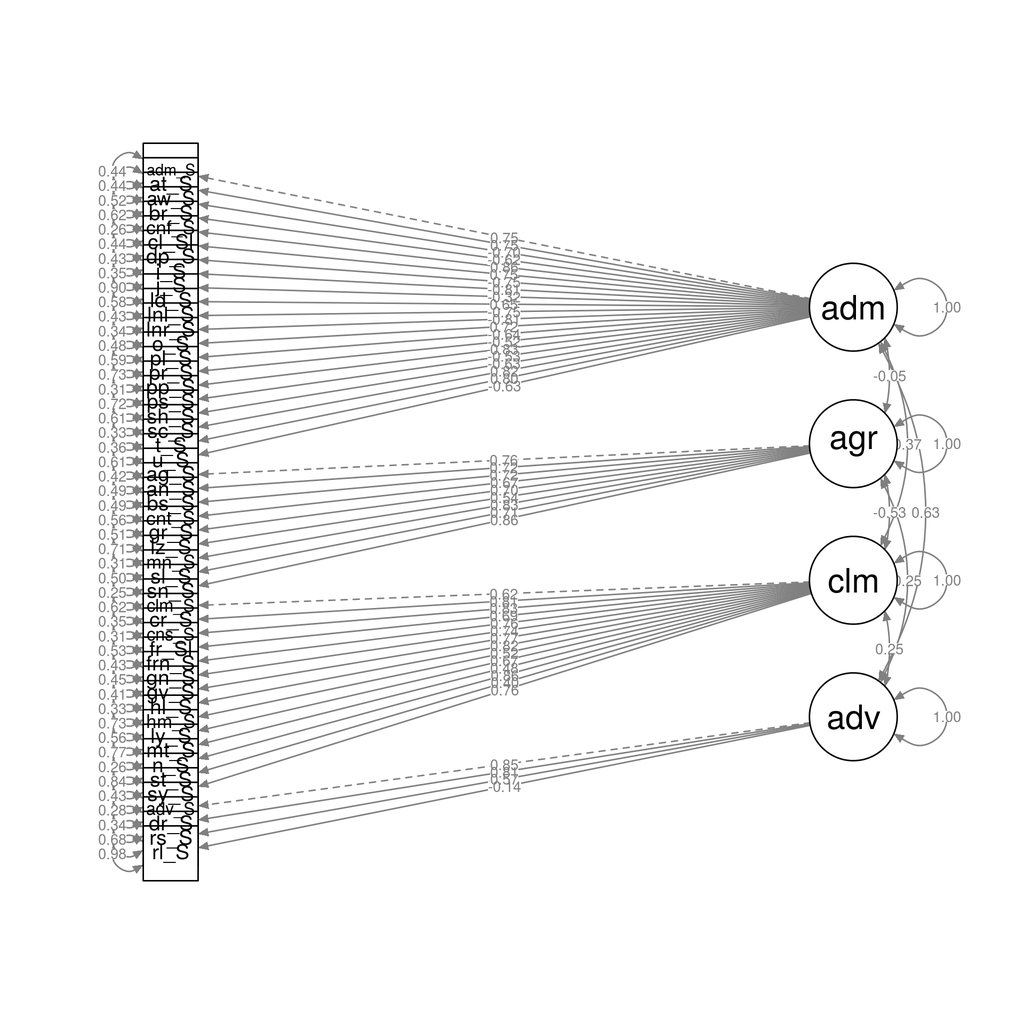

Estimates of reliability vary below between the CFA and the alphas on the raw scales, but I’m not sure why.

```
##           admired agressive      calm adventurous     total
## alpha  0.52932000 0.9079866 0.9257611   0.5009572 0.7827143
## omega  0.10589001 0.9079875 0.9258329   0.6855255 0.7190912
## omega2 0.10589001 0.9079875 0.9258329   0.6855255 0.7190912
## omega3 0.02883272 0.9021183 0.9146480   0.7357847 0.2976845
## avevar 0.50904740 0.5260893 0.4779916   0.4593294 0.5021716
```

```
##
## Reliability analysis
## Call: alpha(x = dataCFA[, itemScaleGroupsCFA$item[itemScaleGroupsCFA$maxPA ==
##     "PA1"]], check.keys = T)
##
##   raw_alpha std.alpha G6(smc) average_r S/N   ase mean  sd
##       0.95      0.95    0.97      0.48  19 0.014  3.2 1.1
##
##  lower alpha upper     95% confidence boundaries
## 0.92 0.95 0.98
##
##  Reliability if an item is dropped:
##                  raw_alpha std.alpha G6(smc) average_r S/N alpha se
## admired_Self-         0.95      0.95    0.97      0.48  18    0.015
## attractive_Self-      0.95      0.95    0.97      0.48  18    0.015
## awkward_Self          0.95      0.95    0.97      0.48  18    0.015
## boring_Self           0.95      0.95    0.97      0.48  19    0.015
## confident_Self-       0.95      0.95    0.97      0.47  18    0.015
## cool_Self-            0.95      0.95    0.97      0.48  18    0.015
## depressed_Self        0.95      0.95    0.97      0.47  18    0.015
## insecure_Self         0.95      0.95    0.97      0.47  18    0.015
## jealous_Self          0.95      0.95    0.97      0.50  20    0.014
## leader_Self-          0.95      0.95    0.97      0.49  19    0.014
## lonely_Self           0.95      0.95    0.97      0.48  18    0.015
## loner_Self            0.95      0.95    0.97      0.47  18    0.015
## outgoing_Self-        0.95      0.95    0.97      0.48  19    0.015
## plain_Self            0.95      0.95    0.97      0.49  19    0.014
## poor_Self             0.95      0.95    0.97      0.49  19    0.014
## popular_Self-         0.95      0.95    0.97      0.47  18    0.015
## pushover_Self         0.95      0.95    0.97      0.49  19    0.014
## shy_Self              0.95      0.95    0.97      0.49  19    0.014
## social_Self-          0.95      0.95    0.97      0.47  18    0.015
## trendy_Self-          0.95      0.95    0.97      0.48  18    0.015
## ugly_Self             0.95      0.95    0.97      0.48  19    0.015
##
##  Item statistics
##                    n raw.r std.r r.cor r.drop mean  sd
## admired_Self-    100  0.72  0.73  0.72   0.69  3.4 1.5
## attractive_Self- 100  0.73  0.74  0.73   0.70  2.9 1.4
## awkward_Self     100  0.74  0.73  0.72   0.70  3.6 1.7
```

[output cut: 27 more lines]

```
## depressed_Self  0.26 0.18 0.18 0.15 0.12 0.10 0.01
## insecure_Self   0.19 0.15 0.15 0.17 0.17 0.17 0.00
## jealous_Self    0.24 0.14 0.28 0.20 0.10 0.04 0.00
## leader_Self     0.14 0.22 0.17 0.22 0.16 0.09 0.00
## lonely_Self     0.22 0.16 0.19 0.21 0.10 0.12 0.00
## loner_Self      0.25 0.18 0.14 0.18 0.13 0.12 0.00
## outgoing_Self   0.19 0.14 0.14 0.15 0.22 0.16 0.00
## plain_Self      0.18 0.17 0.22 0.18 0.14 0.10 0.01
## poor_Self       0.29 0.15 0.22 0.14 0.17 0.03 0.00
## popular_Self    0.17 0.16 0.21 0.23 0.10 0.12 0.01
## pushover_Self   0.27 0.18 0.10 0.21 0.17 0.06 0.01
## shy_Self        0.14 0.12 0.13 0.19 0.20 0.22 0.00
## social_Self     0.11 0.11 0.13 0.26 0.19 0.20 0.00
## trendy_Self     0.15 0.16 0.13 0.28 0.18 0.09 0.01
## ugly_Self       0.35 0.27 0.17 0.10 0.07 0.04 0.00
```

```
##
## Reliability analysis
## Call: alpha(x = dataCFA[, itemScaleGroupsCFA$item[itemScaleGroupsCFA$maxPA ==
##     "PA2"]], check.keys = T)
##
##   raw_alpha std.alpha G6(smc) average_r S/N  ase mean  sd
##       0.91      0.91    0.92      0.53  10 0.03  2.5 1.1
##
##  lower alpha upper     95% confidence boundaries
## 0.85 0.91 0.97
##
##  Reliability if an item is dropped:
##                  raw_alpha std.alpha G6(smc) average_r  S/N alpha se
## agressive_Self        0.90      0.90    0.91      0.52  8.7    0.034
## angry_Self            0.89      0.90    0.90      0.52  8.6    0.035
## bossy_Self            0.90      0.90    0.90      0.53  8.9    0.034
## controlling_Self      0.90      0.90    0.90      0.53  9.1    0.034
## grumpy_Self           0.90      0.90    0.91      0.53  9.1    0.034
## lazy_Self             0.91      0.91    0.92      0.56 10.1    0.032
## mean_Self             0.89      0.89    0.90      0.51  8.4    0.035
## selfish_Self          0.90      0.90    0.91      0.53  8.9    0.034
## snobby_Self           0.89      0.89    0.90      0.51  8.5    0.035
##
##  Item statistics
##                    n raw.r std.r r.cor r.drop mean  sd
## agressive_Self    99  0.78  0.78  0.75   0.71  2.3 1.4
## angry_Self       100  0.80  0.80  0.79   0.74  2.5 1.5
## bossy_Self       100  0.76  0.76  0.73   0.68  2.6 1.5
## controlling_Self 100  0.74  0.74  0.70   0.66  2.6 1.5
## grumpy_Self       99  0.74  0.74  0.71   0.67  2.6 1.5
## lazy_Self         99  0.64  0.63  0.56   0.53  2.6 1.5
## mean_Self        100  0.82  0.82  0.80   0.76  2.2 1.4
## selfish_Self      99  0.76  0.76  0.73   0.69  2.6 1.4
## snobby_Self       99  0.81  0.81  0.79   0.75  2.3 1.5
##
## Non missing response frequency for each item
##                     1    2    3    4    5    6 miss
## agressive_Self   0.42 0.16 0.19 0.12 0.08 0.02 0.01
## angry_Self       0.34 0.24 0.17 0.15 0.05 0.05 0.00
## bossy_Self       0.32 0.22 0.16 0.17 0.09 0.04 0.00
## controlling_Self 0.29 0.29 0.12 0.17 0.09 0.04 0.00
## grumpy_Self      0.29 0.26 0.14 0.15 0.11 0.04 0.01
## lazy_Self        0.31 0.24 0.12 0.19 0.08 0.05 0.01
## mean_Self        0.46 0.17 0.16 0.11 0.09 0.01 0.00
## selfish_Self     0.28 0.24 0.16 0.19 0.10 0.02 0.01
## snobby_Self      0.43 0.20 0.09 0.17 0.08 0.02 0.01
```

```
##
## Reliability analysis
## Call: alpha(x = dataCFA[, itemScaleGroupsCFA$item[itemScaleGroupsCFA$maxPA ==
##     "PA3"]], check.keys = T)
##
##   raw_alpha std.alpha G6(smc) average_r S/N   ase mean   sd
##       0.92      0.93    0.94      0.47  13 0.022  4.6 0.84
##
##  lower alpha upper     95% confidence boundaries
## 0.88 0.92 0.97
##
##  Reliability if an item is dropped:
##                  raw_alpha std.alpha G6(smc) average_r S/N alpha se
## calm_Self             0.92      0.92    0.94      0.48  12    0.023
## caring_Self           0.92      0.92    0.93      0.47  11    0.024
## considerate_Self      0.91      0.92    0.93      0.46  11    0.024
## fair_Self             0.92      0.92    0.93      0.48  12    0.023
## friendly_Self         0.92      0.92    0.93      0.47  12    0.024
## genuine_Self          0.92      0.92    0.93      0.47  11    0.024
## giving_Self           0.92      0.92    0.94      0.47  12    0.024
## helpful_Self          0.92      0.92    0.93      0.47  11    0.024
## humble_Self           0.92      0.93    0.94      0.49  13    0.023
## loyal_Self            0.92      0.92    0.94      0.47  12    0.023
## motivated_Self        0.92      0.93    0.94      0.49  13    0.023
## nice_Self             0.91      0.92    0.93      0.46  11    0.024
## studious_Self         0.93      0.93    0.94      0.50  13    0.022
## sympathetic_Self      0.92      0.92    0.93      0.47  11    0.024
##
##  Item statistics
##                    n raw.r std.r r.cor r.drop mean   sd
## calm_Self         99  0.67  0.67  0.64   0.61  4.4 1.17
## caring_Self      100  0.78  0.78  0.78   0.74  4.7 1.09
## considerate_Self 100  0.81  0.82  0.82   0.78  4.8 1.03
## fair_Self        100  0.71  0.71  0.69   0.66  4.6 1.26
## friendly_Self    100  0.75  0.75  0.74   0.70  4.7 1.26
## genuine_Self     100  0.77  0.78  0.76   0.73  4.7 1.10
## giving_Self      100  0.76  0.75  0.73   0.70  4.6 1.26
## helpful_Self     100  0.78  0.79  0.78   0.74  4.8 1.06
## humble_Self      100  0.58  0.58  0.53   0.50  4.4 1.24
## loyal_Self       100  0.72  0.72  0.69   0.67  4.8 1.20
## motivated_Self    99  0.59  0.58  0.53   0.51  4.4 1.29
## nice_Self        100  0.82  0.83  0.83   0.79  4.9 0.98
## studious_Self    100  0.51  0.50  0.45   0.43  4.4 1.28
## sympathetic_Self  99  0.77  0.76  0.75   0.71  4.5 1.30
##
## Non missing response frequency for each item
##                     1    2    3    4    5    6 miss
## calm_Self        0.01 0.07 0.10 0.28 0.35 0.18 0.01
## caring_Self      0.00 0.04 0.08 0.27 0.32 0.29 0.00
## considerate_Self 0.00 0.02 0.09 0.25 0.34 0.30 0.00
## fair_Self        0.04 0.03 0.07 0.25 0.34 0.27 0.00
## friendly_Self    0.01 0.08 0.09 0.17 0.37 0.28 0.00
## genuine_Self     0.00 0.04 0.08 0.29 0.29 0.30 0.00
## giving_Self      0.01 0.10 0.03 0.31 0.28 0.27 0.00
## helpful_Self     0.00 0.04 0.06 0.27 0.34 0.29 0.00
## humble_Self      0.04 0.02 0.15 0.31 0.29 0.19 0.00
## loyal_Self       0.02 0.04 0.08 0.17 0.39 0.30 0.00
## motivated_Self   0.03 0.07 0.08 0.28 0.31 0.22 0.01
## nice_Self        0.00 0.03 0.05 0.21 0.43 0.28 0.00
## studious_Self    0.02 0.07 0.13 0.31 0.24 0.23 0.00
## sympathetic_Self 0.04 0.04 0.11 0.21 0.35 0.24 0.01
```

```
##
## Reliability analysis
## Call: alpha(x = dataCFA[, itemScaleGroupsCFA$item[itemScaleGroupsCFA$maxPA ==
##     "PA4"]], check.keys = T)
##
##   raw_alpha std.alpha G6(smc) average_r S/N   ase mean  sd
##       0.72      0.71    0.73      0.38 2.4 0.082  3.2 1.1
##
##  lower alpha upper     95% confidence boundaries
## 0.55 0.72 0.88
##
##  Reliability if an item is dropped:
##                    raw_alpha std.alpha G6(smc) average_r S/N alpha se
## adventurous_Self        0.66      0.66    0.58      0.39 1.9    0.108
## daring_Self             0.50      0.50    0.47      0.25 1.0    0.126
## risky_Self              0.60      0.59    0.64      0.33 1.5    0.112
## rulefollower_Self-      0.79      0.78    0.73      0.55 3.6    0.091
##
##  Item statistics
##                      n raw.r std.r r.cor r.drop mean  sd
## adventurous_Self   100  0.73  0.72  0.65   0.49  4.0 1.5
## daring_Self        100  0.87  0.86  0.85   0.73  3.2 1.5
## risky_Self         100  0.79  0.78  0.66   0.58  2.9 1.4
## rulefollower_Self- 100  0.54  0.56  0.34   0.25  2.7 1.4
##
## Non missing response frequency for each item
##                      1    2    3    4    5    6 miss
## adventurous_Self  0.07 0.14 0.12 0.23 0.31 0.13    0
## daring_Self       0.17 0.16 0.16 0.34 0.10 0.07    0
## risky_Self        0.21 0.22 0.23 0.18 0.12 0.04    0
## rulefollower_Self 0.04 0.08 0.11 0.29 0.27 0.21    0
```

What conclusions can we draw? The CFA indicates that we could do better in this model. But the scale alphas coefficients are very good, with even the 4 item adventurous factor getting >.7. However, there are a lot of cross loadings in the EFA, and we totally ignore those, which is why the CFA fit is so shabby. This can especially be the case with many items per scale.